CLDC 12 · Panel: Language and Culture in the Context of LLMs

# Language, Culture, and the Geometry of Meaning

From statistical memory to unalignable islands —  
three lenses on what LLMs possibly learn.

Presenter Shu-Kai Hsieh

Affiliation GIL, National Taiwan University

Date May 1, 2026

[figure not shown]

Overview

## 10 Minutes, 3 Lenses, 1 Thought

01 Statistical  
Memory (The Surface)

- Investigating the nature of encoded cultural data
- LLMs as weighted averages of cultural expression

2 min

02 Culture as  
Protocol (The Interaction)

- Diagnostic assessment of communicative application through benchmarks.

3 min

03 Latent  
Geometry (The Structure)

- Mapping the spatial distribution of concepts
- Tracking cultural drift in embedding space

3 min

04 Unalignable  
Islands (The Boundary)

- When translation is not enough
- Identifying the limits of cross-lingual alignment.

2 min

Opening question: What exactly does an LLM "learn" when it learns a language?

Lens 1 · Statistical Memory

## Corpus signal: lexical residue after 2022

2016 → 2023

[figure not shown]

Post-2022 frequencies jump sharply in both corpora. The lexical surge is consistent with a model-mediated style diffusion, where repeated AI phrasing becomes statistically self-reinforcing.(https://github.com/FareedKhan-dev/Detect-AI-text-Easily)

Signal: distinctive AI-flavored phrasing reveals the statistical residue of the training distribution, check [Wikipedia: Signs of AI writing]](https://en.wikipedia.org/wiki/Wikipedia:Signs%20of%20AI%20writing?oldformat=true#Language_and_grammar)

Lens 1 · Statistical Memory

## Emergent agent-to-agent communication often diverges from human natural language

[figure not shown]

SoMolt · 詞頻分析: dominant n-grams read as machine-shaped residue, not ordinary conversational language. [A Monitoring Corpus for Agent Communication](https://lopen.linguistics.ntu.edu.tw/somo/)

Lens 1 · Statistical Memory

## Culture as a Probability Distribution/Probabilistic Flattening

→ LLMs don't *understand* culture; they mirror the **frequency of its expression**

→ In a "weighted average," the loudest (most data-heavy) cultures become the ground truth

→ Minority cultures aren't simply unknown — they're force-fit into dominant frameworks; LLMs do not merely "forget" minority cultures; rather, they perform a form of "cultural colonization" by subsuming low-resource nuances under high-probability (Western) dominant equivalents.

Framing: whose language dominates the mix becomes the implicit prior in model output.

Lens 2 · Diagnostic Benchmarking of Implicit Cultural Protocols and Pragmatic Inference in LLMs

## LLM Cultural Benchmarking

The Problem Facts aren't enough

Culture isn't "What is the capital of Taiwan?" — it's **social coherence**: pragmatics, indirectness, code-switching, face-saving.

LOBSTER · ROCLING 2025 96 IOL problems · 90+ languages:  
Measures Linguistic Diversity and structural reasoning

Evaluates LLMs on *linguistic reasoning* with typological metadata. Goes beyond final-answer accuracy — grades **reasoning chains** too. Iterative MoA significantly outperforms single-pass.

[IOL-like Saisiyat example](https://www.uklo.org/wp-content/uploads/2025/04/2025R1-3-Saisiyat.pdf)

BETEL · In progress Taiwanese Culture Benchmark:  
Measures Cultural Pragmatics and social context

Diagnoses cultural "traps" a global model systematically fails — pragmatic inference, code-switching, culturally situated deixis.

[Cultural-Contextual Comprehension Task](https://docs.google.com/presentation/d/1DgBahdx1PcNUzI989VzUKM6QujVa9099EkCR9bRjbjk/edit?slide=id.g3dece824992_2_960#slide=id.g3dece824992_2_960)

Key Finding Alignment ≠ translation

Gemini-2.5-Pro scores **0.44** on LOBSTER baseline. Low-resource languages (Class 0) see near-zero E→T generation. Language family predicts failure, not script. Linguistic diversity is not just about diverse text; it is about diverse cognitive and structural frameworks that current alignment methods often fail to bridge.

Lens 3 · Shared Latent Space

## The Semantic Manifold of 情 (Qing)

Utilize "情" (Qing) to illustrate curvature shifts between Classical and Modern Chinese, and the semantic divergence between Chinese embeddings and Western-centric translations (Emotion/Sentiment).

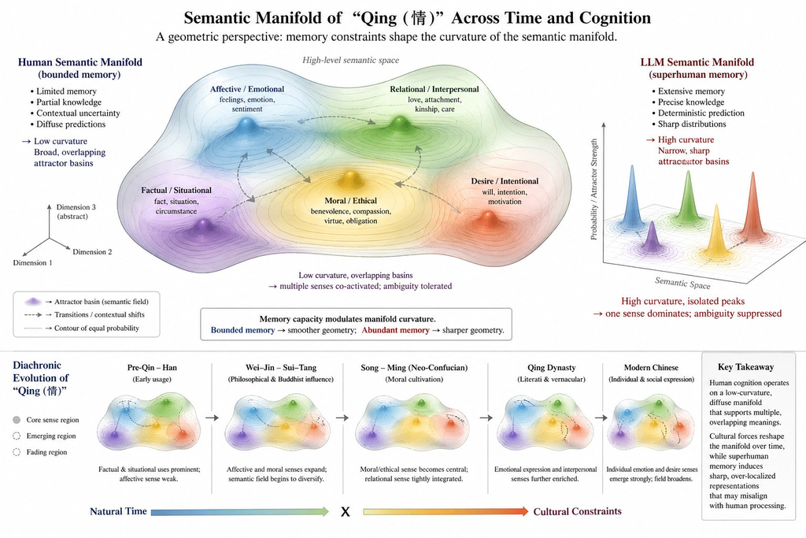

Diachronic sense tagging of 「情」 (Pre-Qin → Modern): memory capacity modulates manifold curvature — human cognition tolerates ambiguity, LLMs suppress it.

Thought · The Unalignable Issue

## Some Concepts Refuse to Align

辛苦了 Pragmatic example

LLMs map this to "Good job." But in the Taiwanese / East Asian context it acknowledges **shared burden** — vertical social pressure, *suffering-as-virtue*. No English equivalent carries that weight.

阿公 Diachronic example

Beyond "Grandfather" — a social honorific for elderly males, with Hokkien-Mandarin code-switching, political-historical affect, and emotional warmth that English cannot encode in a single word.

Benchmark goal: not to fix "errors," but to identify unalignable islands — where our language *refuses to be a weighted average* of a global norm.

Closing Provocation

We are not just training models  
to speak our language —  
we are defending the right  
of our languag/culture to have its own geometry.

**Statistical Memory** Culture = probability distribution. Loudest datasets win.

**Communicative Protocol** Benchmark the invisible handshake, not just the facts.

**Unalignable Islands** Preserve unique curvatures. Don't flatten for efficiency.

1 / 9